# Chapther 3 Exercises

Abel Isaias Gutierrez-Cruz

13/7/2021

## *Exercise 3.1*

A hiking enthusiast has a new app for his smartphone which summarizes his hikes by using a GPS device. Let us look at the distance hiked (in km) and maximum altitude (in m) for the last 10 hikes:

| Distance | 12.5 | 29.9 | 14.8 | 18.7 | 7.6 | 16.2 | 16.5 | 27.4 | 12.1 | 17.5 |
| --- | --- | --- | --- | --- | --- | --- | --- | --- | --- | --- |
| Altitude | 342 | 1245 | 502 | 555 | 398 | 670 | 796 | 912 | 238 | 466 |

1. Calculate the arithmetic mean and median for both distance and altitude.

```r
distance <- c(12.5, 29.9, 14.8, 18.7, 7.6, 16.2, 16.5, 27.4, 12.1, 17.5)
distance <- distance[order(distance)]
altitude <- c(342, 1245, 502, 555, 398, 670, 796, 912, 238, 466)
altitude <- altitude[order(altitude)]
data_exercise3_1 <- data.frame(distance = distance, altitude = altitude)
```

Mean and median Distance

```r
summarize(data_exercise3_1, mean_distance = mean(distance), median_distance = median(distance))
```

```
##   mean_distance median_distance
## 1         17.32           16.35
```

Mean and median Altitude

```r
summarize(data_exercise3_1, mean_altitude = mean(altitude), median_altitude = median(altitude))
```

```
##   mean_altitude median_altitude
## 1         612.4           528.5
```

2. Determine the first and third quartiles for both the distance and the altitude variables. Discuss the shape of the distribution given the results of (a) and (b).

```r
#"Quartiles disntance"
quartile_distance <- quantile(data_exercise3_1$distance, probs = c(0.25, 0.75), type = 2)

#"Quartiles altitude"
quartile_altitude <- quantile(data_exercise3_1$altitude, probs = c(0.25, 0.75), type = 2)
```

```r
summary(data_exercise3_1)
```

```
##     distance        altitude
##  Min.   : 7.60   Min.   : 238.0
##  1st Qu.:13.07   1st Qu.: 415.0
##  Median :16.35   Median : 528.5
##  Mean   :17.32   Mean   : 612.4
##  3rd Qu.:18.40   3rd Qu.: 764.5
##  Max.   :29.90   Max.   :1245.0
```

3. Calculate the interquartile range, absolute median deviation, and variance for both variables. What is your conclusion about the variability of the data?

> To calculate de variance we need to multiply the result by $(n-1)/n$, because R uses $1/(n-1)$ rather than $1/n$ when calculating the variance

```r
amd <- function(x){1/length(x)*sum(abs(x-median(x)))}
# Interquartile distance
quartile_distance[[2]] - quartile_distance[[1]]
```

```
## [1] 6.2
```

```r
# Absolute median deviation distance
amd(data_exercise3_1$distance)
```

```
## [1] 4.68
```

```r
# Variance distance
var(data_exercise3_1$distance)*9/10
```

```
## [1] 41.5036
```

```r
# Interquartile altitude
quartile_altitude[[2]] - quartile_altitude[[1]]
```

```
## [1] 398
```

```r
# Absolute median deviation altitude
amd(data_exercise3_1$altitude)
```

```
## [1] 223.2
```

```r
# variance altitude
var(data_exercise3_1$altitude)*9/10
```

```
## [1] 82314.44
```

4. One metre corresponds to approximately 3.28 ft. What is the average altitude when measured in feet rather than in metres?

$\bar{y} = a + b\bar{x}$

$\tilde{s}_y^2 = b^2\tilde{s}_x^2$

```r
# Mean
3.28*mean(data_exercise3_1$altitude)
```

```
## [1] 2008.672
```

```r
# Variance
(3.28^2)*(var(data_exercise3_1$altitude)*9/10)
```

```
## [1] 885571.7
```

5. Draw and interpret the box plot for both distance and altitude.

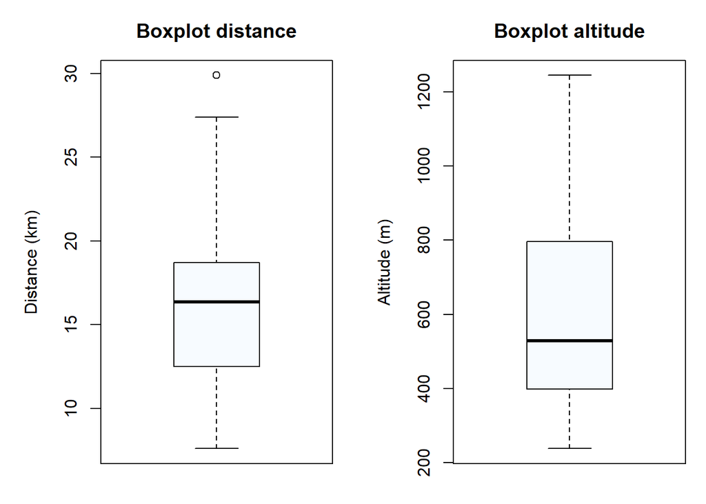

```r
par(mfrow = c(1, 2), mar = c(2, 5, 3, 1))
boxplot(data_exercise3_1$distance, main = "Boxplot distance", col = blues9, ylab = "Distance (km)")
boxplot(data_exercise3_1$altitude, main = "Boxplot altitude", col = blues9, ylab = "Altitude (m)")
```

6. Assume distance is measured as only short (5–15 km), moderate (15–20 km), and long (20–30 km). Summarize the grouped data in a frequency table. Calculate the weighted arithmetic mean under the assumption that the raw data is not known. Determine the weighted median under the assumption that the values within each class are equally distributed.

```r
groups <- c(5, 15, 20, 30)
labels_distances <- c("1", "2", "3")
grouped_distance <- cut(distance, breaks = groups, labels = labels_distances, right = FALSE)
data_exercise3_1$groups <- grouped_distance

relative_frecuency <- as.data.frame(table(grouped_distance)/nrow(data_exercise3_1))
# get the weithted arithmetic mean
middle_values <- groups[1:3] + (diff(groups)/2)
weighted.mean(middle_values, relative_frecuency$Freq)
```

```
## [1] 16
```

Estimate the weighted median:

```r
groups[2] + ((0.5 - relative_frecuency$Freq[1])/relative_frecuency$Freq[1])*(diff(groups)[2])
```

```
## [1] 16.25
```

## *Exercise 3.2*

A gambler notes down his wins and losses (in euros) from playing 10 games of roulette in a casino.

| Round | Won/Lost |
| --- | --- |
| 1 | 200 |
| 2 | 600 |
| 3 | −200 |
| 4 | −200 |
| 5 | −200 |
| 6 | −100 |
| 7 | −100 |
| 8 | −400 |
| 9 | 0 |

1. Assume $\bar{x}$ = − 90 euros and s = 294.7881 euros. What is the result of round 10?

$\bar{x} = \dfrac{1}{n}\sum\limits_{i=1}^nx_i$

$-90 = \dfrac{1}{10}(-400 + X)$

$X = (-90\times 10) + 400$

```r
won_lost = c(200, 600, -200, -200, -200, -100, -100, -400, 0)
data_exercise3_2 <- data.frame(round = 1:10, won_lost = c(won_lost, ((-90*10) - sum(won_lost))))
kable(data_exercise3_2)
```

| round | won_lost |
| --- | --- |
| 1 | 200 |
| 2 | 600 |
| 3 | -200 |
| 4 | -200 |
| 5 | -200 |
| 6 | -100 |
| 7 | -100 |
| 8 | -400 |
| 9 | 0 |
| 10 | -500 |

```r
Modes <- function(x) {
  ux <- unique(x)
  tab <- tabulate(match(x, ux))
  ux[tab == max(tab)]
}

Modes(data_exercise3_2$won_lost)
```

```
## [1] -200
```

3. A different gambler plays 33 rounds of roulette. His results are $\bar{x}$ = 12 euros and s = 1000 euros. Is it meaningful to compare the variability of results of the two players by using the coefficient of variation? If yes, determine the coefficients of variation; if no, why is a comparison not possible?

It isn’t possible to estimate the coefficient of variation because some of the values are negative